# Optimal Treatment Analysis

## Outcome Variable

**Outcome Variable:** haz

## Predictor Variables

**Intervention Variable:** rain_quartile

**Adjustment Set:**

unadjusted

## Stratifying Variables

The analysis was stratified on these variable(s):

- studyid
- country
- agecat

## Data Summary

| studyid | country | agecat | rain_quartile | n_cell | n |
| --- | --- | --- | --- | --- | --- |
| CMC-V-BCS-2002 | India | Birth | 1 | 18 | 92 |
| CMC-V-BCS-2002 | India | Birth | 2 | 25 | 92 |
| CMC-V-BCS-2002 | India | Birth | 3 | 30 | 92 |
| CMC-V-BCS-2002 | India | Birth | 4 | 19 | 92 |
| CMC-V-BCS-2002 | India | 6 months | 1 | 101 | 369 |
| CMC-V-BCS-2002 | India | 6 months | 2 | 111 | 369 |
| CMC-V-BCS-2002 | India | 6 months | 3 | 97 | 369 |
| CMC-V-BCS-2002 | India | 6 months | 4 | 60 | 369 |
| CMC-V-BCS-2002 | India | 24 months | 1 | 101 | 371 |
| CMC-V-BCS-2002 | India | 24 months | 2 | 99 | 371 |
| CMC-V-BCS-2002 | India | 24 months | 3 | 116 | 371 |
| CMC-V-BCS-2002 | India | 24 months | 4 | 55 | 371 |
| CMIN | Bangladesh | Birth | 1 | 7 | 26 |
| CMIN | Bangladesh | Birth | 2 | 6 | 26 |
| CMIN | Bangladesh | Birth | 3 | 6 | 26 |
| CMIN | Bangladesh | Birth | 4 | 7 | 26 |
| CMIN | Bangladesh | 6 months | 1 | 50 | 243 |
| CMIN | Bangladesh | 6 months | 2 | 62 | 243 |
| CMIN | Bangladesh | 6 months | 3 | 71 | 243 |
| CMIN | Bangladesh | 6 months | 4 | 60 | 243 |
| CMIN | Bangladesh | 24 months | 1 | 78 | 242 |
| CMIN | Bangladesh | 24 months | 2 | 69 | 242 |
| CMIN | Bangladesh | 24 months | 3 | 58 | 242 |
| CMIN | Bangladesh | 24 months | 4 | 37 | 242 |
| CONTENT | Peru | Birth | 1 | 0 | 2 |
| CONTENT | Peru | Birth | 2 | 2 | 2 |
| CONTENT | Peru | Birth | 3 | 0 | 2 |
| CONTENT | Peru | Birth | 4 | 0 | 2 |
| CONTENT | Peru | 6 months | 1 | 62 | 215 |
| CONTENT | Peru | 6 months | 2 | 32 | 215 |

[output cut: 238 more lines]

The following strata were considered:

- studyid: CMC-V-BCS-2002, country: India, agecat: 24 months
- studyid: CMC-V-BCS-2002, country: India, agecat: 6 months
- studyid: CMC-V-BCS-2002, country: India, agecat: Birth
- studyid: CMIN, country: Bangladesh, agecat: 24 months
- studyid: CMIN, country: Bangladesh, agecat: 6 months
- studyid: CMIN, country: Bangladesh, agecat: Birth
- studyid: CONTENT, country: Peru, agecat: 24 months
- studyid: CONTENT, country: Peru, agecat: 6 months
- studyid: CONTENT, country: Peru, agecat: Birth
- studyid: EE, country: Pakistan, agecat: 24 months
- studyid: EE, country: Pakistan, agecat: 6 months
- studyid: EE, country: Pakistan, agecat: Birth
- studyid: GMS-Nepal, country: Nepal, agecat: 24 months
- studyid: GMS-Nepal, country: Nepal, agecat: 6 months
- studyid: GMS-Nepal, country: Nepal, agecat: Birth
- studyid: Guatemala BSC, country: Guatemala, agecat: 6 months
- studyid: IRC, country: India, agecat: 24 months
- studyid: IRC, country: India, agecat: 6 months
- studyid: IRC, country: India, agecat: Birth
- studyid: JiVitA-3, country: Bangladesh, agecat: 24 months
- studyid: JiVitA-3, country: Bangladesh, agecat: 6 months
- studyid: JiVitA-3, country: Bangladesh, agecat: Birth
- studyid: JiVitA-4, country: Bangladesh, agecat: 24 months
- studyid: JiVitA-4, country: Bangladesh, agecat: 6 months
- studyid: JiVitA-4, country: Bangladesh, agecat: Birth
- studyid: Keneba, country: Gambia, agecat: 24 months
- studyid: Keneba, country: Gambia, agecat: 6 months
- studyid: Keneba, country: Gambia, agecat: Birth
- studyid: LCNI-5, country: Malawi, agecat: 24 months
- studyid: LCNI-5, country: Malawi, agecat: 6 months
- studyid: MAL-ED, country: Bangladesh, agecat: 24 months
- studyid: MAL-ED, country: Bangladesh, agecat: 6 months
- studyid: MAL-ED, country: Bangladesh, agecat: Birth
- studyid: MAL-ED, country: Brazil, agecat: 24 months
- studyid: MAL-ED, country: Brazil, agecat: 6 months
- studyid: MAL-ED, country: Brazil, agecat: Birth
- studyid: MAL-ED, country: India, agecat: 24 months
- studyid: MAL-ED, country: India, agecat: 6 months
- studyid: MAL-ED, country: India, agecat: Birth
- studyid: MAL-ED, country: Nepal, agecat: 24 months
- studyid: MAL-ED, country: Nepal, agecat: 6 months
- studyid: MAL-ED, country: Nepal, agecat: Birth
- studyid: MAL-ED, country: Peru, agecat: 24 months
- studyid: MAL-ED, country: Peru, agecat: 6 months
- studyid: MAL-ED, country: Peru, agecat: Birth
- studyid: MAL-ED, country: South Africa, agecat: 24 months
- studyid: MAL-ED, country: South Africa, agecat: 6 months
- studyid: MAL-ED, country: South Africa, agecat: Birth
- studyid: MAL-ED, country: Tanzania, agecat: 24 months
- studyid: MAL-ED, country: Tanzania, agecat: 6 months
- studyid: MAL-ED, country: Tanzania, agecat: Birth
- studyid: PROBIT, country: Belarus, agecat: 24 months
- studyid: PROBIT, country: Belarus, agecat: 6 months
- studyid: PROBIT, country: Belarus, agecat: Birth
- studyid: PROVIDE, country: Bangladesh, agecat: 24 months
- studyid: PROVIDE, country: Bangladesh, agecat: 6 months
- studyid: PROVIDE, country: Bangladesh, agecat: Birth
- studyid: ResPak, country: Pakistan, agecat: 6 months
- studyid: ResPak, country: Pakistan, agecat: Birth
- studyid: SAS-CompFeed, country: India, agecat: 6 months
- studyid: SAS-CompFeed, country: India, agecat: Birth
- studyid: SAS-FoodSuppl, country: India, agecat: 6 months
- studyid: TanzaniaChild2, country: Tanzania, agecat: 24 months
- studyid: TanzaniaChild2, country: Tanzania, agecat: 6 months
- studyid: ZVITAMBO, country: Zimbabwe, agecat: 24 months
- studyid: ZVITAMBO, country: Zimbabwe, agecat: 6 months
- studyid: ZVITAMBO, country: Zimbabwe, agecat: Birth

### Dropped Strata

Some strata were dropped due to rare outcomes:

- studyid: CONTENT, country: Peru, agecat: Birth
- studyid: EE, country: Pakistan, agecat: Birth
- studyid: EE, country: Pakistan, agecat: 6 months
- studyid: EE, country: Pakistan, agecat: 24 months
- studyid: GMS-Nepal, country: Nepal, agecat: Birth
- studyid: GMS-Nepal, country: Nepal, agecat: 6 months
- studyid: GMS-Nepal, country: Nepal, agecat: 24 months
- studyid: ResPak, country: Pakistan, agecat: Birth
- studyid: TanzaniaChild2, country: Tanzania, agecat: 24 months

## Methods Detail

We’re interested in the causal parameters $E[Y_a]$ for all values of $a \in \mathcal{A}$. These parameters represent the mean outcome if, possibly contrary to fact, we intervened to set all units to have $A=a$. Under the randomization and positivity assumptions, these are identified by the statistical parameters $\psi_a=E_W[E_{Y|A,W}(Y|A=a,W)]$. In addition, we’re interested in the mean of $Y$, $E[Y]$ under no intervention (the observed mean). We will estimate these parameters by using SuperLearner to fit the relevant likelihood factors – $E_{Y|A,W}(Y|A=a,W)$ and $p(A=a|W)$, and then updating our likelihood fit using a joint TMLE.

For unadjusted analyses ($W=\{\}$), initial likelihoods were estimated using Lrnr_glm to estimate the simple $E(Y|A)$ and Lrnr_mean to estimate $p(A)$. For adjusted analyses, a small library containing Lrnr_glmnet, Lrnr_xgboost, and Lrnr_mean was used.

Having estimated these parameters, we will then use the delta method to estimate relative risks and attributable risks relative to a prespecified baseline level of $A$.

# Results Detail

## Results Plots

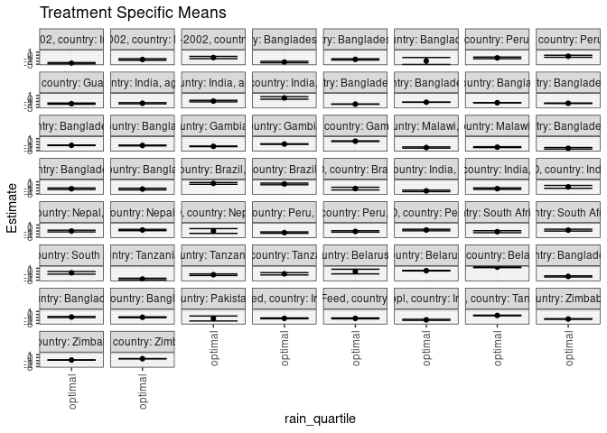

## Results Table

### Parameter: TSM

| studyid | country | agecat | intervention_level | baseline_level | estimate | ci_lower | ci_upper |
| --- | --- | --- | --- | --- | --- | --- | --- |
| CMC-V-BCS-2002 | India | Birth | optimal | observed | -0.7939622 | -1.1797176 | -0.4082068 |
| CMC-V-BCS-2002 | India | 6 months | optimal | observed | -1.4253756 | -1.6940800 | -1.1566713 |
| CMC-V-BCS-2002 | India | 24 months | optimal | observed | -2.6904422 | -2.9100075 | -2.4708768 |
| CMIN | Bangladesh | Birth | optimal | observed | -1.9341071 | -3.0883810 | -0.7798332 |
| CMIN | Bangladesh | 6 months | optimal | observed | -1.3941698 | -1.6151054 | -1.1732341 |
| CMIN | Bangladesh | 24 months | optimal | observed | -2.2910745 | -2.5396666 | -2.0424824 |
| CONTENT | Peru | 6 months | optimal | observed | -0.3547829 | -0.6943013 | -0.0152645 |
| CONTENT | Peru | 24 months | optimal | observed | -0.8983114 | -1.1728616 | -0.6237612 |
| Guatemala BSC | Guatemala | 6 months | optimal | observed | -1.7582219 | -1.9503301 | -1.5661138 |
| IRC | India | Birth | optimal | observed | 0.1508730 | -0.2796446 | 0.5813906 |
| IRC | India | 6 months | optimal | observed | -0.9061557 | -1.1718118 | -0.6404997 |
| IRC | India | 24 months | optimal | observed | -1.6207441 | -1.8105618 | -1.4309264 |
| JiVitA-3 | Bangladesh | Birth | optimal | observed | -1.4500748 | -1.4876711 | -1.4124785 |
| JiVitA-3 | Bangladesh | 6 months | optimal | observed | -1.2695682 | -1.3126002 | -1.2265361 |
| JiVitA-3 | Bangladesh | 24 months | optimal | observed | -1.9141221 | -1.9690533 | -1.8591909 |
| JiVitA-4 | Bangladesh | Birth | optimal | observed | -1.2912980 | -1.4247187 | -1.1578773 |
| JiVitA-4 | Bangladesh | 6 months | optimal | observed | -1.2378486 | -1.3197814 | -1.1559158 |
| JiVitA-4 | Bangladesh | 24 months | optimal | observed | -1.6217810 | -1.7065198 | -1.5370422 |
| Keneba | Gambia | Birth | optimal | observed | 0.1387642 | 0.0180944 | 0.2594339 |
| Keneba | Gambia | 6 months | optimal | observed | -0.8244995 | -0.9152144 | -0.7337846 |
| Keneba | Gambia | 24 months | optimal | observed | -1.5870727 | -1.6887536 | -1.4853917 |
| LCNI-5 | Malawi | 6 months | optimal | observed | -1.8634429 | -2.0105038 | -1.7163821 |
| LCNI-5 | Malawi | 24 months | optimal | observed | -1.9825767 | -2.1926140 | -1.7725394 |
| MAL-ED | Bangladesh | Birth | optimal | observed | -1.4142895 | -1.6834056 | -1.1451734 |
| MAL-ED | Bangladesh | 6 months | optimal | observed | -1.3200632 | -1.5747226 | -1.0654037 |
| MAL-ED | Bangladesh | 24 months | optimal | observed | -2.2339661 | -2.4936791 | -1.9742530 |
| MAL-ED | Brazil | Birth | optimal | observed | -1.2636871 | -1.7187237 | -0.8086505 |
| MAL-ED | Brazil | 6 months | optimal | observed | 0.2857168 | 0.0080564 | 0.5633773 |
| MAL-ED | Brazil | 24 months | optimal | observed | 0.4706112 | 0.1666681 | 0.7745543 |
| MAL-ED | India | Birth | optimal | observed | -0.6892502 | -1.1643998 | -0.2141005 |
| MAL-ED | India | 6 months | optimal | observed | -1.2833826 | -1.5239176 | -1.0428475 |
| MAL-ED | India | 24 months | optimal | observed | -2.0294955 | -2.2785649 | -1.7804261 |
| MAL-ED | Nepal | Birth | optimal | observed | -1.0018533 | -1.7964920 | -0.2072147 |
| MAL-ED | Nepal | 6 months | optimal | observed | -0.6670337 | -0.8854161 | -0.4486514 |
| MAL-ED | Nepal | 24 months | optimal | observed | -1.0167228 | -1.3045838 | -0.7288619 |
| MAL-ED | Peru | Birth | optimal | observed | -0.6660182 | -0.9216095 | -0.4104269 |
| MAL-ED | Peru | 6 months | optimal | observed | -1.1395851 | -1.3778654 | -0.9013047 |
| MAL-ED | Peru | 24 months | optimal | observed | -1.5352526 | -1.7712338 | -1.2992713 |
| MAL-ED | South Africa | Birth | optimal | observed | -0.5370925 | -0.9833251 | -0.0908598 |
| MAL-ED | South Africa | 6 months | optimal | observed | -0.7110282 | -1.0125308 | -0.4095256 |
| MAL-ED | South Africa | 24 months | optimal | observed | -1.2303087 | -1.5680795 | -0.8925380 |
| MAL-ED | Tanzania | Birth | optimal | observed | -0.8730653 | -1.2558588 | -0.4902717 |
| MAL-ED | Tanzania | 6 months | optimal | observed | -1.1655799 | -1.4262628 | -0.9048969 |
| MAL-ED | Tanzania | 24 months | optimal | observed | -2.6095746 | -2.8751343 | -2.3440150 |
| PROBIT | Belarus | Birth | optimal | observed | 1.3693295 | 1.1975836 | 1.5410755 |
| PROBIT | Belarus | 6 months | optimal | observed | 0.1887242 | 0.0861479 | 0.2913006 |
| PROBIT | Belarus | 24 months | optimal | observed | -0.1149096 | -0.8891548 | 0.6593356 |
| PROVIDE | Bangladesh | Birth | optimal | observed | -0.9485451 | -1.0771307 | -0.8199595 |
| PROVIDE | Bangladesh | 6 months | optimal | observed | -0.8732332 | -1.0465877 | -0.6998786 |
| PROVIDE | Bangladesh | 24 months | optimal | observed | -1.7370337 | -1.9316642 | -1.5424033 |
| ResPak | Pakistan | 6 months | optimal | observed | -1.3650755 | -2.1997778 | -0.5303733 |
| SAS-CompFeed | India | Birth | optimal | observed | -1.3137866 | -1.4624821 | -1.1650912 |
| SAS-CompFeed | India | 6 months | optimal | observed | -1.3085853 | -1.4410899 | -1.1760808 |
| SAS-FoodSuppl | India | 6 months | optimal | observed | -1.8072379 | -1.9769658 | -1.6375100 |
| TanzaniaChild2 | Tanzania | 6 months | optimal | observed | -0.3492602 | -0.4535022 | -0.2450181 |
| ZVITAMBO | Zimbabwe | Birth | optimal | observed | -0.3648940 | -0.4030012 | -0.3267868 |
| ZVITAMBO | Zimbabwe | 6 months | optimal | observed | -0.7951845 | -0.8461911 | -0.7441779 |
| ZVITAMBO | Zimbabwe | 24 months | optimal | observed | -1.5385313 | -1.6359540 | -1.4411085 |

### Parameter: E(Y)

| studyid | country | agecat | intervention_level | baseline_level | estimate | ci_lower | ci_upper |
| --- | --- | --- | --- | --- | --- | --- | --- |
| CMC-V-BCS-2002 | India | Birth | observed | observed | -0.9611957 | -1.1776967 | -0.7446946 |
| CMC-V-BCS-2002 | India | 6 months | observed | observed | -1.4234508 | -1.5645974 | -1.2823042 |
| CMC-V-BCS-2002 | India | 24 months | observed | observed | -2.5588679 | -2.6583730 | -2.4593629 |
| CMIN | Bangladesh | Birth | observed | observed | -1.8811538 | -2.5124807 | -1.2498270 |
| CMIN | Bangladesh | 6 months | observed | observed | -1.7844376 | -1.9222926 | -1.6465825 |
| CMIN | Bangladesh | 24 months | observed | observed | -2.5109504 | -2.6361514 | -2.3857494 |
| CONTENT | Peru | 6 months | observed | observed | -0.2785256 | -0.4098735 | -0.1471776 |
| CONTENT | Peru | 24 months | observed | observed | -0.6868598 | -0.8388476 | -0.5348719 |
| Guatemala BSC | Guatemala | 6 months | observed | observed | -1.5619008 | -1.6727702 | -1.4510313 |
| IRC | India | Birth | observed | observed | -0.3080412 | -0.4687931 | -0.1472894 |
| IRC | India | 6 months | observed | observed | -1.2344062 | -1.3658524 | -1.1029600 |
| IRC | India | 24 months | observed | observed | -1.7987775 | -1.8923914 | -1.7051636 |
| JiVitA-3 | Bangladesh | Birth | observed | observed | -1.5894148 | -1.6086362 | -1.5701935 |
| JiVitA-3 | Bangladesh | 6 months | observed | observed | -1.3130932 | -1.3362359 | -1.2899505 |
| JiVitA-3 | Bangladesh | 24 months | observed | observed | -2.0131862 | -2.0408408 | -1.9855316 |
| JiVitA-4 | Bangladesh | Birth | observed | observed | -1.5232908 | -1.5723277 | -1.4742539 |
| JiVitA-4 | Bangladesh | 6 months | observed | observed | -1.3447940 | -1.3820261 | -1.3075620 |
| JiVitA-4 | Bangladesh | 24 months | observed | observed | -1.7807218 | -1.8162478 | -1.7451958 |
| Keneba | Gambia | Birth | observed | observed | 0.0308036 | -0.0328378 | 0.0944451 |
| Keneba | Gambia | 6 months | observed | observed | -0.9036375 | -0.9508087 | -0.8564663 |
| Keneba | Gambia | 24 months | observed | observed | -1.5774356 | -1.6272400 | -1.5276311 |
| LCNI-5 | Malawi | 6 months | observed | observed | -1.6601907 | -1.7297701 | -1.5906113 |
| LCNI-5 | Malawi | 24 months | observed | observed | -1.8861485 | -1.9671802 | -1.8051169 |
| MAL-ED | Bangladesh | Birth | observed | observed | -1.1180952 | -1.2525408 | -0.9836496 |
| MAL-ED | Bangladesh | 6 months | observed | observed | -1.2049931 | -1.3222136 | -1.0877726 |
| MAL-ED | Bangladesh | 24 months | observed | observed | -1.9783962 | -2.1050210 | -1.8517715 |
| MAL-ED | Brazil | Birth | observed | observed | -0.6760000 | -0.9521457 | -0.3998543 |
| MAL-ED | Brazil | 6 months | observed | observed | 0.0475758 | -0.0963508 | 0.1915023 |
| MAL-ED | Brazil | 24 months | observed | observed | 0.0061144 | -0.1625850 | 0.1748138 |
| MAL-ED | India | Birth | observed | observed | -1.2036170 | -1.4976814 | -0.9095527 |
| MAL-ED | India | 6 months | observed | observed | -1.2115254 | -1.3298727 | -1.0931782 |
| MAL-ED | India | 24 months | observed | observed | -1.8861894 | -2.0110006 | -1.7613783 |
| MAL-ED | Nepal | Birth | observed | observed | -0.8533333 | -1.2104864 | -0.4961803 |
| MAL-ED | Nepal | 6 months | observed | observed | -0.5615819 | -0.6741832 | -0.4489807 |
| MAL-ED | Nepal | 24 months | observed | observed | -1.3075877 | -1.4270718 | -1.1881037 |
| MAL-ED | Peru | Birth | observed | observed | -0.8827897 | -1.0001058 | -0.7654736 |
| MAL-ED | Peru | 6 months | observed | observed | -1.3236661 | -1.4316775 | -1.2156546 |
| MAL-ED | Peru | 24 months | observed | observed | -1.7524710 | -1.8736426 | -1.6312994 |
| MAL-ED | South Africa | Birth | observed | observed | -0.6317073 | -0.8249555 | -0.4384591 |
| MAL-ED | South Africa | 6 months | observed | observed | -1.0633202 | -1.1909180 | -0.9357224 |
| MAL-ED | South Africa | 24 months | observed | observed | -1.6450595 | -1.7797240 | -1.5103950 |
| MAL-ED | Tanzania | Birth | observed | observed | -1.1556000 | -1.3655361 | -0.9456639 |
| MAL-ED | Tanzania | 6 months | observed | observed | -1.3687449 | -1.4907629 | -1.2467270 |
| MAL-ED | Tanzania | 24 months | observed | observed | -2.6455607 | -2.7807256 | -2.5103959 |
| PROBIT | Belarus | Birth | observed | observed | 1.3114417 | 1.1524752 | 1.4704082 |
| PROBIT | Belarus | 6 months | observed | observed | 0.0980074 | 0.0062724 | 0.1897424 |
| PROBIT | Belarus | 24 months | observed | observed | -0.1442891 | -0.4253755 | 0.1367972 |
| PROVIDE | Bangladesh | Birth | observed | observed | -0.8851020 | -0.9601332 | -0.8100709 |
| PROVIDE | Bangladesh | 6 months | observed | observed | -1.0916915 | -1.1661176 | -1.0172654 |
| PROVIDE | Bangladesh | 24 months | observed | observed | -1.6024221 | -1.6857420 | -1.5191023 |
| ResPak | Pakistan | 6 months | observed | observed | -1.4314086 | -1.6374838 | -1.2253335 |
| SAS-CompFeed | India | Birth | observed | observed | -1.4314217 | -1.5099245 | -1.3529189 |
| SAS-CompFeed | India | 6 months | observed | observed | -1.4018563 | -1.4810585 | -1.3226541 |
| SAS-FoodSuppl | India | 6 months | observed | observed | -1.8986842 | -2.0118892 | -1.7854792 |
| TanzaniaChild2 | Tanzania | 6 months | observed | observed | -0.5434389 | -0.5924056 | -0.4944722 |
| ZVITAMBO | Zimbabwe | Birth | observed | observed | -0.5002724 | -0.5208163 | -0.4797285 |
| ZVITAMBO | Zimbabwe | 6 months | observed | observed | -0.8679450 | -0.8935071 | -0.8423828 |
| ZVITAMBO | Zimbabwe | 24 months | observed | observed | -1.6055701 | -1.6625562 | -1.5485840 |

### Parameter: PAR

| studyid | country | agecat | intervention_level | baseline_level | estimate | ci_lower | ci_upper |
| --- | --- | --- | --- | --- | --- | --- | --- |
| CMC-V-BCS-2002 | India | Birth | optimal | observed | -0.1672335 | -0.4883800 | 0.1539131 |
| CMC-V-BCS-2002 | India | 6 months | optimal | observed | 0.0019249 | -0.2316589 | 0.2355087 |
| CMC-V-BCS-2002 | India | 24 months | optimal | observed | 0.1315742 | -0.0701750 | 0.3333234 |
| CMIN | Bangladesh | Birth | optimal | observed | 0.0529533 | -1.0818324 | 1.1877389 |
| CMIN | Bangladesh | 6 months | optimal | observed | -0.3902678 | -0.5998365 | -0.1806991 |
| CMIN | Bangladesh | 24 months | optimal | observed | -0.2198760 | -0.4394559 | -0.0002960 |
| CONTENT | Peru | 6 months | optimal | observed | 0.0762573 | -0.2271072 | 0.3796218 |
| CONTENT | Peru | 24 months | optimal | observed | 0.2114517 | -0.0254568 | 0.4483601 |
| Guatemala BSC | Guatemala | 6 months | optimal | observed | 0.1963212 | 0.0158273 | 0.3768150 |
| IRC | India | Birth | optimal | observed | -0.4589142 | -0.8310610 | -0.0867675 |
| IRC | India | 6 months | optimal | observed | -0.3282505 | -0.5466640 | -0.1098370 |
| IRC | India | 24 months | optimal | observed | -0.1780334 | -0.3479317 | -0.0081352 |
| JiVitA-3 | Bangladesh | Birth | optimal | observed | -0.1393400 | -0.1721664 | -0.1065137 |
| JiVitA-3 | Bangladesh | 6 months | optimal | observed | -0.0435250 | -0.0783569 | -0.0086932 |
| JiVitA-3 | Bangladesh | 24 months | optimal | observed | -0.0990641 | -0.1455076 | -0.0526206 |
| JiVitA-4 | Bangladesh | Birth | optimal | observed | -0.2319928 | -0.3635605 | -0.1004251 |
| JiVitA-4 | Bangladesh | 6 months | optimal | observed | -0.1069455 | -0.1848226 | -0.0290683 |
| JiVitA-4 | Bangladesh | 24 months | optimal | observed | -0.1589408 | -0.2386211 | -0.0792605 |
| Keneba | Gambia | Birth | optimal | observed | -0.1079605 | -0.2152180 | -0.0007031 |
| Keneba | Gambia | 6 months | optimal | observed | -0.0791380 | -0.1569113 | -0.0013647 |
| Keneba | Gambia | 24 months | optimal | observed | 0.0096371 | -0.0750711 | 0.0943452 |
| LCNI-5 | Malawi | 6 months | optimal | observed | 0.2032522 | 0.0728237 | 0.3336808 |
| LCNI-5 | Malawi | 24 months | optimal | observed | 0.0964282 | -0.0905250 | 0.2833814 |
| MAL-ED | Bangladesh | Birth | optimal | observed | 0.2961942 | 0.0603928 | 0.5319957 |
| MAL-ED | Bangladesh | 6 months | optimal | observed | 0.1150701 | -0.0966025 | 0.3267426 |
| MAL-ED | Bangladesh | 24 months | optimal | observed | 0.2555698 | 0.0204125 | 0.4907272 |
| MAL-ED | Brazil | Birth | optimal | observed | 0.5876871 | 0.1253475 | 1.0500267 |
| MAL-ED | Brazil | 6 months | optimal | observed | -0.2381411 | -0.4674684 | -0.0088138 |
| MAL-ED | Brazil | 24 months | optimal | observed | -0.4644968 | -0.7626298 | -0.1663637 |
| MAL-ED | India | Birth | optimal | observed | -0.5143669 | -0.9909194 | -0.0378144 |
| MAL-ED | India | 6 months | optimal | observed | 0.0718571 | -0.1462728 | 0.2899871 |
| MAL-ED | India | 24 months | optimal | observed | 0.1433061 | -0.0745493 | 0.3611615 |
| MAL-ED | Nepal | Birth | optimal | observed | 0.1485200 | -0.5956220 | 0.8926620 |
| MAL-ED | Nepal | 6 months | optimal | observed | 0.1054518 | -0.0867040 | 0.2976076 |
| MAL-ED | Nepal | 24 months | optimal | observed | -0.2908649 | -0.5570814 | -0.0246484 |
| MAL-ED | Peru | Birth | optimal | observed | -0.2167715 | -0.4449418 | 0.0113988 |
| MAL-ED | Peru | 6 months | optimal | observed | -0.1840810 | -0.3937384 | 0.0255764 |
| MAL-ED | Peru | 24 months | optimal | observed | -0.2172184 | -0.4182236 | -0.0162132 |
| MAL-ED | South Africa | Birth | optimal | observed | -0.0946148 | -0.4360688 | 0.2468392 |
| MAL-ED | South Africa | 6 months | optimal | observed | -0.3522920 | -0.6297422 | -0.0748418 |
| MAL-ED | South Africa | 24 months | optimal | observed | -0.4147508 | -0.7245988 | -0.1049027 |
| MAL-ED | Tanzania | Birth | optimal | observed | -0.2825347 | -0.6173564 | 0.0522869 |
| MAL-ED | Tanzania | 6 months | optimal | observed | -0.2031651 | -0.4368185 | 0.0304884 |
| MAL-ED | Tanzania | 24 months | optimal | observed | -0.0359861 | -0.2631430 | 0.1911708 |
| PROBIT | Belarus | Birth | optimal | observed | -0.0578878 | -0.1005415 | -0.0152341 |
| PROBIT | Belarus | 6 months | optimal | observed | -0.0907168 | -0.1395741 | -0.0418595 |
| PROBIT | Belarus | 24 months | optimal | observed | -0.0293795 | -0.6437396 | 0.5849806 |
| PROVIDE | Bangladesh | Birth | optimal | observed | 0.0634431 | -0.0543049 | 0.1811911 |
| PROVIDE | Bangladesh | 6 months | optimal | observed | -0.2184583 | -0.3720827 | -0.0648340 |
| PROVIDE | Bangladesh | 24 months | optimal | observed | 0.1346116 | -0.0330707 | 0.3022939 |
| ResPak | Pakistan | 6 months | optimal | observed | -0.0663331 | -0.9006563 | 0.7679901 |
| SAS-CompFeed | India | Birth | optimal | observed | -0.1176351 | -0.2284260 | -0.0068443 |
| SAS-CompFeed | India | 6 months | optimal | observed | -0.0932710 | -0.2112977 | 0.0247558 |
| SAS-FoodSuppl | India | 6 months | optimal | observed | -0.0914463 | -0.2235146 | 0.0406220 |
| TanzaniaChild2 | Tanzania | 6 months | optimal | observed | -0.1941787 | -0.2821924 | -0.1061650 |
| ZVITAMBO | Zimbabwe | Birth | optimal | observed | -0.1353785 | -0.1684421 | -0.1023149 |
| ZVITAMBO | Zimbabwe | 6 months | optimal | observed | -0.0727605 | -0.1163974 | -0.0291236 |
| ZVITAMBO | Zimbabwe | 24 months | optimal | observed | -0.0670389 | -0.1435972 | 0.0095195 |